# Professor: Alejandro Llorente Pinto

# Section 2

## Analyzing the graph

In this section, we will use Igraph functions to analyze some basic features:

1. Is the graph connected? If it is not, compute the connected components and analyze the statistical distribution of the size of the resulting components. Do this considering all the links but also using only the different types of edges.
2. Analyze the statistical distribution of the “weight” attribute created in the previous section and fit it to a power law distribution. Does it fit well enough?

```r
# 1. Is the graph connected.
vertex_connectivity(g, source = NULL, target = NULL, checks = TRUE)
```

```
## [1] 0
```

```r
is.connected(g2)
```

```
## [1] FALSE
```

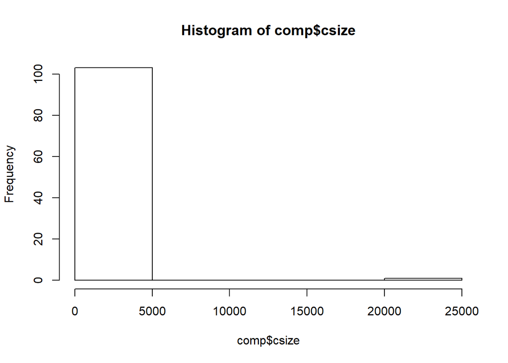

```r
comp = components(g2, mode = c("weak", "strong"))
hist(comp$csize)
```

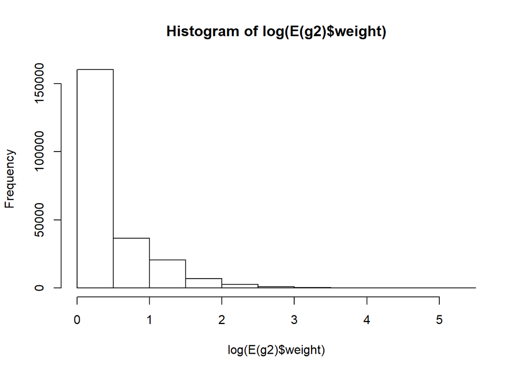

```r
# 2. Analyze the statistical distribution of the "weight" attribute
hist(log(E(g2)$weight))
```

```r
power.law.fit((E(g2)$weight))
```

```
## $continuous
## [1] FALSE
##
## $alpha
## [1] 3.107498
##
## $xmin
## [1] 5
##
## $logLik
## [1] -23978.95
##
## $KS.stat
## [1] 0.01481846
##
## $KS.p
## [1] 0.01863459
```

1. There are 0 connectivity within the nodes and when checking the is.connected function we can see it is not. As shown in the graph, there is only one component big enough to take into consideration.
2. The graph shows us that the weight distribution is skewed to the right, being most of the weights smaller to 20 (links/edges). As for the power law, we reject the Kolmogorov-Smirnov test which infers that the original data could not have been drawn from the fitted power-law distribution.